```r
knitr::opts_chunk$set(error = TRUE)
```

AUTHOR: Hamayun Khan

GetYourGuide Goal: Suggest a set of features that will help predict Revenue per Click (RPC)

# 0. Load Data

```r
training = read.csv("train.csv")
library(caret)
library(doParallel)
library(stringr)
if(!require("lubridate")) install.packages("lubridate"); library("lubridate")
library(zoo)
if(!require("tikzDevice")) install.packages("tikzDevice"); library("tikzDevice")
require(tikzDevice)
source("1.0 Helper.R")
```

```r
source("3.0 Main.R")
if(!require("corrplot")) install.packages("corrplot"); library("corrplot")
set.seed(123)
idx_1 = createDataPartition(y = train$Revenue, p = 0.05, list = FALSE)
train = training[idx_1,]
train = data_setup(train)
train = time_features(train)
```

# Contents

1. Data Exploration
2. Feature Creation
3. Feature Selection
4. Conclusion
5. Next Steps

## 1. Data Exploration

```r
str(train)
```

```
## 'data.frame':    414272 obs. of  22 variables:
##  $ Date                : Date, format: "2014-12-14" "2014-12-14" ...
##  $ Keyword_ID          : num  6.50e+11 7.84e+11 7.53e+11 1.92e+11 1.54e+11 ...
##  $ Ad_group_ID         : num  3.16e+11 1.06e+11 5.09e+11 6.56e+11 9.24e+11 ...
##  $ Campaign_ID         : num  7.82e+11 3.07e+11 5.51e+11 6.96e+11 1.07e+12 ...
##  $ Account_ID          : Factor w/ 16 levels "151664859558",..: 9 12 3 12 14 14 12 4 4 4 ...
##  $ Device_ID           : Factor w/ 3 levels "298643508640",..: 1 3 1 3 2 1 1 2 1 2 ...
##  $ Match_type_ID       : Factor w/ 3 levels "95725474456",..: 1 2 1 3 3 3 3 3 3 3 ...
##  $ Revenue             : num  0 0 0 0 0 0 0 0 0 0 ...
##  $ Clicks              : int  2 2 2 2 2 2 2 2 5 2 ...
##  $ Conversions         : int  0 0 0 0 0 0 0 0 0 0 ...
##  $ Account_Device      : Factor w/ 48 levels "151664859558 1077718730738",..: 26 34 8 34 42 41 35 12 11 12 ...
##  $ Account_Match       : Factor w/ 48 levels "151664859558 872544605608",..: 27 34 9 35 41 41 35 11 11 11 ...
##  $ Match_Device        : Factor w/ 9 levels "872544605608 1077718730738",..: 8 1 8 4 6 5 5 6 5 6 ...
##  $ Account_Match_Device: Factor w/ 144 levels "151664859558 872544605608 1077718730738",..: 80 100 26 103 123 122 104 33 32 33 ...
##  $ rpc                 : num  0 0 0 0 0 0 0 0 0 0 ...
##  $ log.rpc             : num  0 0 0 0 0 0 0 0 0 0 ...
##  $ price.paid          : num  0 0 0 0 0 0 0 0 0 0 ...
##  $ booking             : Factor w/ 2 levels "0","1": 1 1 1 1 1 1 1 1 1 1 ...
##  $ month               : Factor w/ 5 levels "1","2","3","4",..: 5 5 5 5 5 5 5 5 5 5 ...
##  $ year.month          : Factor w/ 5 levels "2014-12","2015-01",..: 1 1 1 1 1 1 1 1 1 1 ...
##  $ weekday             : Factor w/ 7 levels "1","2","3","4",..: 1 1 1 1 1 1 1 1 1 1 ...
##  $ day.of.the.month    : Factor w/ 31 levels "1","2","3","4",..: 14 14 14 14 14 14 14 14 14 14 ...
```

The train set consists of roughly 8.3 million observations of 10 variables, which can be divided into three categories: ###1.1 Dates ###1.2 Factors ###1.3 Performance Metrics (not available in the Prediction Set)

### 1.1 Dates

We have from 5 months i.e. Dec 2014, Jan-April 2015. In order to better capture the impact of time, we can transform the date variable into weeks, weekdays and months. These are helpful in understanding the differences across the Factors as well as the Performance Metrics.

For instance, the 5th day of the week has the highest average revenue:

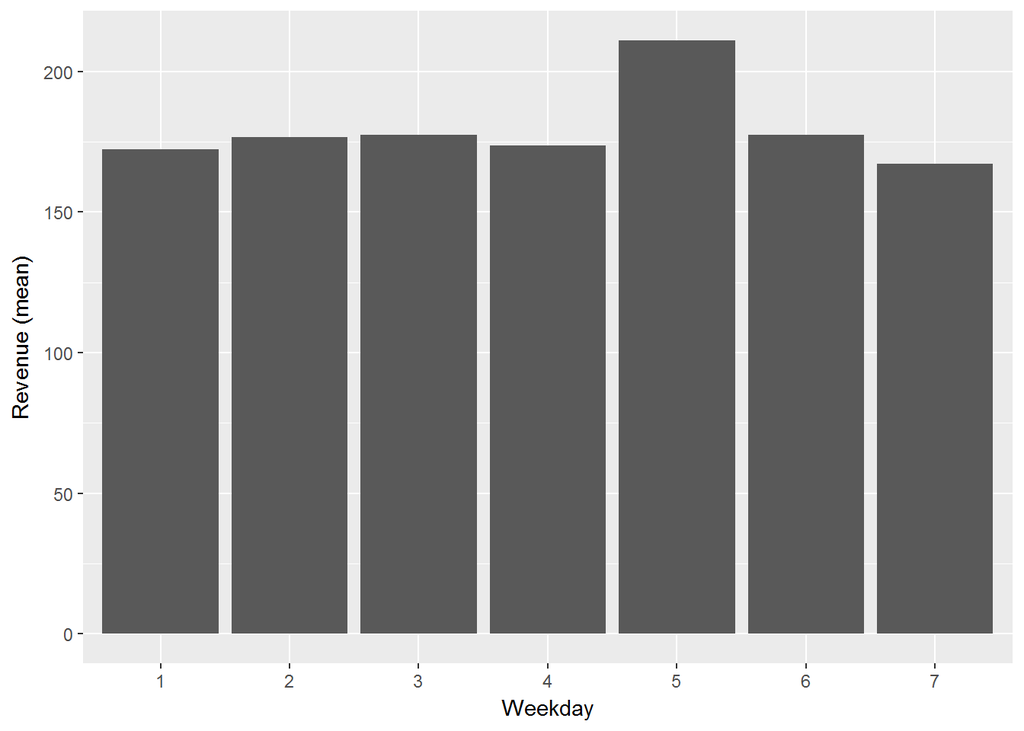

```r
ggplot(data = train,
       aes(weekday, Revenue)) +
  stat_summary(fun.y = mean, geom = "bar") + labs(x = "Weekday", y = "Revenue (mean)")
```

### 1.2 Factors

There are 487,981 unique Keywords, 269,480 unique Ad Groups, 2,927 unique Campaigns and 16 unique Accounts. I marked these variables, along with Devide and Match type, as Factors. (See “3.0 Main.R”) While the number of factor levels for Accounts, Device and Match type are relatively low, the others are very high and are likely to be more informative if they are treated (to be discussed later)

### 1.3 Performance Metrics

Performance metrics include Revenue, Clicks and Conversions which are given. RPC is the target variable and is calculated as Revenue/Clciks. It follows a heavily skewed distribution (around 0), however there are also some very high values.

```r
summary(train$rpc)
```

```
##     Min.  1st Qu.   Median     Mean  3rd Qu.     Max.
##     0.00     0.00     0.00    51.25     0.00 92069.92
```

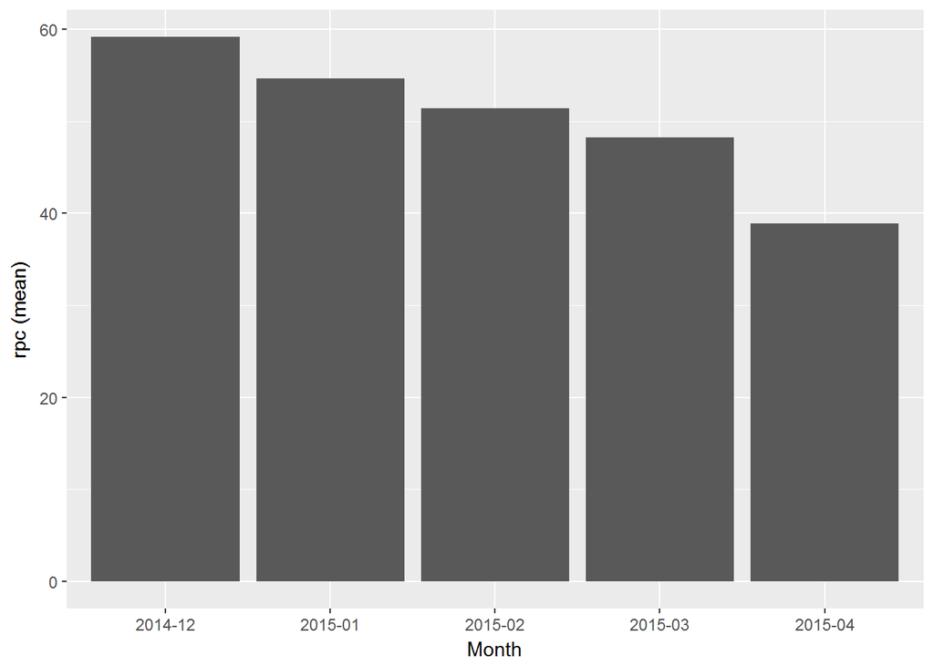

```r
ggplot(data = train,
       aes(year.month, rpc)) +
  stat_summary(fun.y = mean, geom = "bar") + labs(x = "Month", y = "rpc (mean)")
```

In order to address the high values, I suggest using a log transformation. The high number of 0’s in the dataset pose a problem, however, using the log(x + 1) transformation does the trick. The target variable can be de-transformed after prediction using the exponential function i.e. exp(x)-1.

```r
summary(train$log.rpc)
```

```
##    Min. 1st Qu.  Median    Mean 3rd Qu.    Max.
##  0.0000  0.0000  0.0000  0.1394  0.0000 11.4303
```

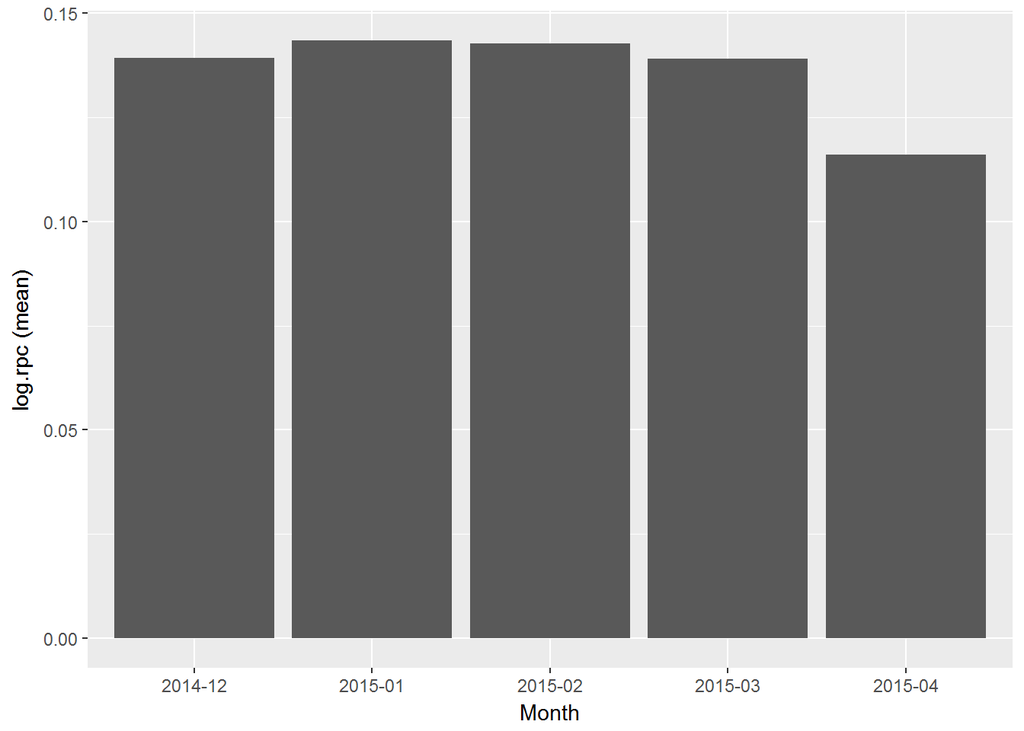

```r
ggplot(data = train,
       aes(year.month, log.rpc)) +
  stat_summary(fun.y = mean, geom = "bar") + labs(x = "Month", y = "log.rpc (mean)")
```

Looking at the two plots, we can see a shift in the distribution. RPC seems to be slowly declining starting in December, whereas log.rpc first increases after December and then declines as we head into April. It’s clear from these plots that there is an underlying time trend that needs to be identified in order to get a good forecast for RPC.

```r
par(mar=c(1,1,1,1))
```

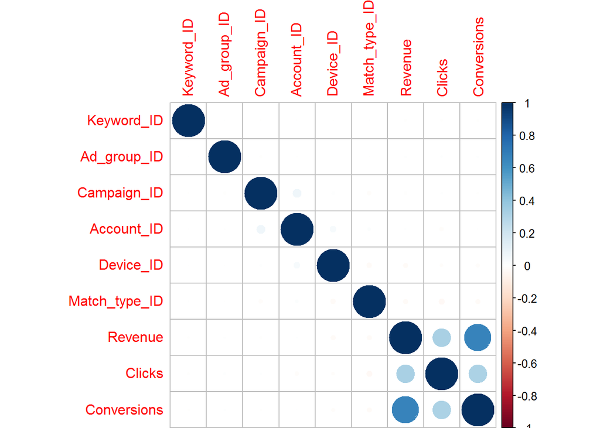

```r
corrplot(cor(training[,-c(1)]), method = "circle")
```

The corrplot shown above appears to tell us that strong correlations only exist between the various Performance Metrics.

There are two points to note here. First, this does not mean that Keywords, or Accounts for instance, have little bearing on RPC. It is quite likely a consquence of having factors with a very high number of levels such that a meaningful relationship becomes difficult to establish. It tells us that we need to address this issue in order to give our model the chance to correctly predict revenue.

Second, Features that contain information about Revenue, Clicks and Conversions will be important for predicting RPC.

### 1.4. Data Exploration: Concluding Thoughts

- Identify time trend in the Data
- Create features that provide information about Performance Metrics
- Address high factor levels in Keywords, Ad Groups and Campaigns

## 2. Feature Creation

### 2.1 Time Trend

Month: Month of the Year

```r
summary(train$month)
```

```
##      1      2      3      4     12
## 108699 106772 120641  31731  46429
```

Year-Month: Created primarily to help visualize the time trend

```r
summary(train$year.month)
```

```
## 2014-12 2015-01 2015-02 2015-03 2015-04
##   46429  108699  106772  120641   31731
```

Weekday: Maps the week from 1-7

```r
summary(train$weekday)
```

```
##     1     2     3     4     5     6     7
## 60247 58329 54950 51390 60267 59423 69666
```

Day.of.the.Month: Maps the month from 1-31

```r
summary(train$day.of.the.month)
```

```
##     1     2     3     4     5     6     7     8     9    10    11    12
## 14550 15102 14149 14228 15412 14828 14401 10828 10277  9958  9934 10851
##    13    14    15    16    17    18    19    20    21    22    23    24
## 10653 13639 13895 13195 23839 12972 13980 13730 13736 14037 13921 13966
##    25    26    27    28    29    30    31
## 14227 14595 14528 14310 10370 10057 10104
```

### 2.2 Performance Metrics

I used a simple linear model to predict Clicks, Revenue, Conversions and logistic model Bookings (since its a binary variable). The idea is to create reliable estimates of these variables using a portion for of the Train set (let’s call it Train-1) and predict these variables for the remaining Train set (let’s call it Train-2) as well as the Prediction set. These estimates can then be used as features for a model trained on Train-2 which predicts our Prediction set.

e.g. see below for a prediction of revenue

First, split into training and test sets

```r
set.seed(124)
idx_2 = createDataPartition(y = train$rpc, p = 0.05, list = FALSE)
trainset = train[idx_2,]
testset = train[-idx_2,]
```

Remove unwanted columns

```r
trainset$booking = NULL
trainset$log.rpc = NULL
trainset$rpc = NULL
trainset$Conversions = NULL
trainset$Clicks = NULL
```

Enable parallel processing and train the model

```r
cl <- makeCluster(detectCores()-1)
registerDoParallel(cl)
ols = caret::train(Revenue~., method = "lm", data = trainset)
stopCluster(cl)
```

Create Feature for testset and Prediction set

```r
testset$Revenue_feature = predict(lr, newdata = testset)
prediction$Revenue_feature = predict(lr, newdata = prediction)
```

### 2.3 High Factor Levels

There are a number of common approaches used to address high factor levels such as Clustering, PCA, Binning. Here I consider Weight of Evidence, which is a supervised (based on the target variable) approach that converts factor variables with high levels into numeric variables.

The klaR package can be used to compute the WOE Object based on the Train set and it is then applied to the Prediction set. Before it can be applied, however, we need to ensure the Prediction set does not have any new factor levels.

```r
train_factors = train[,c(2:7)] #select factors to be checked
prediction.new.levels = check_new_levels(train = train_factors, prediction = prediction)
```

In this case, we have:

- 26,189 new levels in Keywords
- 17,995 new levels in Ad_Groups
- 33 new levels in Campaigns

Ideally, we should compare the new levels to the existing ones and come up with an imputation strategy. However, here I choose to index the new levels and set them to zero as I believe the improvement in predictive power somewhat justifies the loss of information.

### 2.4 Interaction Terms

I created 4 interaction terms to capture joint effects of the variables with low factor levels:

- Account_Device: Capture bookings with particular Account-Device combinations
- Account_Match: Capture bookings with particular Account-Match combinations
- Match_Device: Capture bookings with particular Match-Device combinations
- Account_Match_Device: Capture bookings with particular Account-Match-Device Combinations

### 2.5 Additional Features

Price.paid: Calculates average price paid for a booking by dividing Revenue by Conversions Booking: Binary factor that takes value 1 when revenue is greater than 0 and 0 otherwise

### 2.6 Closest Neighbors

Once all other features have been created, we can use KNN to find the distance between bookings and non-bookings. The function get_dist is trained on the testset as it will contain all the predicted features.

```r
prediction$dist = get_dist(trainSet = testset, predSet = prediction, k = 5) #predict distance on Prediction set
testset$dist = get_dist(trainSet = testset, predSet = testset, k = 5)#get distance for testset
```

## 3. Feature Selection

A number of methods are available for selecting the final set of features. I consider the following two here:

### 3.1 Variable Importance Plot

We can use the variable importance provided by Caret to select the best Features, see below:

```r
testset$Revenue = NULL
testset$Clicks = NULL
testset$rpc = NULL
testset$Conversions = NULL
testset$booking = NULL
testset$dist = NULL
cl <- makeCluster(detectCores()-1)
registerDoParallel(cl)
time.start <- Sys.time()
print(paste0("Model started at: ", time.start))
ols = caret::train(log.rpc~., method = "lm", data = testset)
time.end <- Sys.time()
dur <- time.end-time.start
print( dur )
stopCluster(cl)
varImp(ols)
```

| Variable Importance | Score |
| --- | --- |
| day.of.the.month30 | 100.00 |
| day.of.the.month29 | 93.79 |
| day.of.the.month12 | 86.84 |
| day.of.the.month23 | 81.22 |
| weekday5 | 81.18 |
| Account_Match_Device | 77.50 |
| day.of.the.month27 | 72.77 |
| Campaign_ID | 64.82 |
| Account_Device602182847798 | 60.32 |
| Account_Device412971074791 | 59.34 |

### 3.2 Correlation

Use the following function to drop new Features that are strongly correlated to each other

```r
strongly_correlated = function(dataset, threshold = 0.7)

{

  correlation_matrix = cor(dataset[, sapply(dataset, is.numeric)]) # calculate matrix only for numeric columns

  listed_variables = vector() # vector of listed variables to prevent duplication

  dropped_variables = vector()# vector of variables that will be dropped



  for(column in colnames(correlation_matrix))

  {

    listed_variables = append(listed_variables, column) # add column to listed variables

    # loop only over variables for which we have not calculated the correlation yet

    for(row in setdiff(row.names(correlation_matrix),listed_variables))

    {

      if(abs(correlation_matrix[row,column]) > threshold)

      {

        if(mean(abs(correlation_matrix[row,])) > mean(abs(correlation_matrix[,column])))

        {

          dropped_variables = append(dropped_variables, row)

        }

        else{dropped_variables = append(dropped_variables, column)}

      }

    }

  }

  # return unique variable names

  return(unique(dropped_variables))

}
```

## 4. Conclusions

- Exploratory Analysis hinted towards an underlying time trend. Looking at variable importance, we can see that the time features are among the best predictors of log.rpc
- Simple interaction terms capture important relationships even at the Account level
- Replacing high factor levels with numeric values (using WOE) should make it easier for algorithms to identify the impact of these levels
- Further iterations are required optimize the feature creation process, specifically with regards to the ID columns

## 5. Next Steps

Here are some unfinished ideas I had about the dataset:

### 5.1 Feature Creation

- Number of Clicks/Conversions in the last Week, Month
- Mean number of Clicks for each Keyword when booked as a proportion of the Total Mean
- Percentage Price.Paid deviation in the last Week/Month
- Percentage deviation in Conversions in the last Week/Month

### 5.2 Feature Selection

- Recursive/Stagewise Model building to select best combination of Features

Thank you for your time!